# Fitting logseries and negative binomial SADs with random forests

## Infering the scale of a truncated negative binomial

The zero-truncated negative binomial can be parameterized to represent most all log-normal distributions (given finite data) and in the limit of $k = 0$ is exactly Fisher’s log-series. So it’s a good distribution to see if we can properly parameterize with random forests.

### Species abundances simulated using pika package

```r
# parameters for the negative binomial
mu <- 10
k <- seq(1, 6, length.out = 6)

# parameters for the log-series maintaining the mean
p <- uniroot(function(p) -1/log(1 - p) * p / (1 - p) - mu,
             c(.Machine$double.eps, 1 - .Machine$double.eps))$root
b <- -log(p)

# simulation parameters
nsim <- 100
nspp <- 500

# simulate negative binomial SADs
negbSAD <- rtnegb(nsim * nspp * length(k), mu = mu, k = rep(k, each = nsim * nspp))
negbSAD <- split(negbSAD, rep(1:(nsim * length(k)), each = nspp))
param <- rep(k, each = nsim)

# add to that fisher SADs
fishSAD <- rfish(nsim * nspp, beta = b)
fishSAD <- split(fishSAD, rep(1:nsim, each = nspp))

allSAD <- c(negbSAD, fishSAD)
allParam <- c(param, rep(0, nsim))
```

### Random forest fitting

First let’s make sure the RF won’t just be picking up something simple like a spurious difference in means.

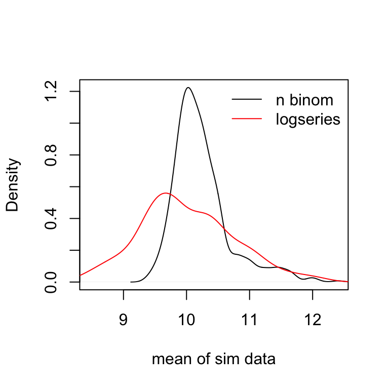

```r
plot(density(sapply(negbSAD, mean)), xlim = range(sapply(allSAD, mean)),
     xlab = 'mean of sim data', main = '')
lines(density(sapply(fishSAD, mean)), col = 'red')
legend('topright', legend = c('n binom', 'logseries'),
       col = c('black', 'red'), lty = 1, bty = 'n')
```

The means of means are close for each distribution, but logseries has more variability in means across simulations. I think that’s ok.

Now on to the fitting with RF based on Renyi entropy

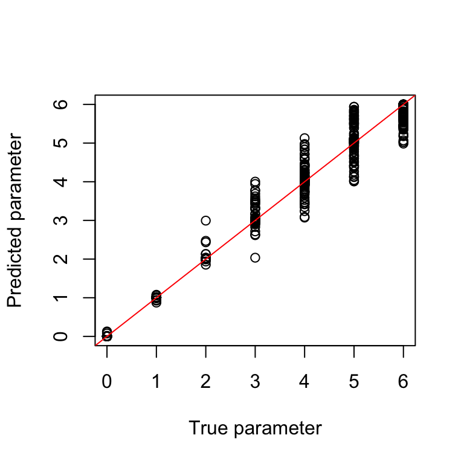

```r
# summary statistic of Renyi entropies
sumStat <- t(sapply(allSAD, renyi))

# run the random forest
rf <- randomForest(sumStat, allParam)

# see how well prediction works
plot(allParam, rf$predicted, xlab = 'True parameter', ylab = 'Predicted parameter')
abline(0, 1, col = 'red')
```

The prediction looks pretty good!

I’m curious to see if using different weights in the Renyi entropy makes a difference. For example, paying more attention to rare species

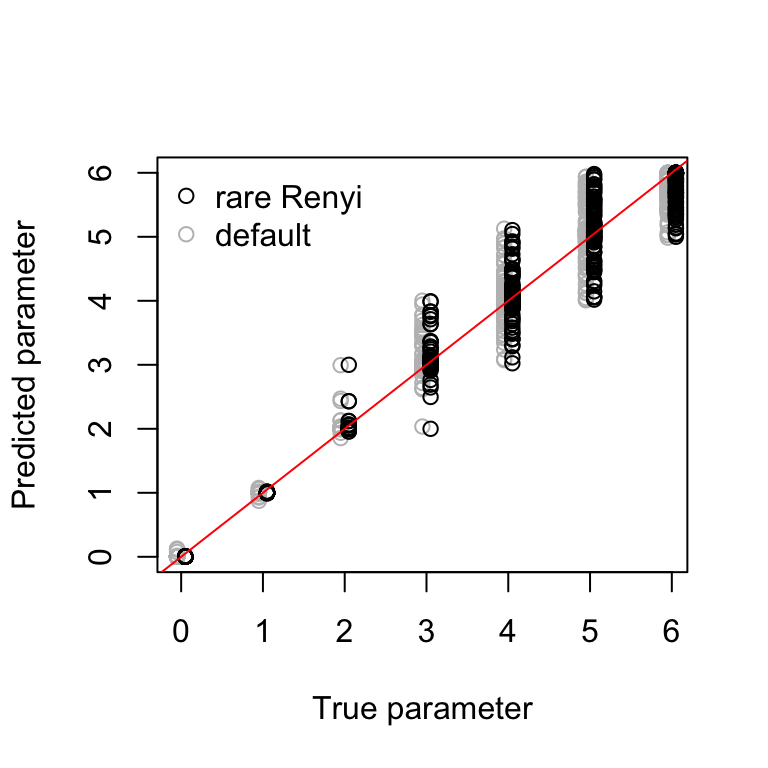

```r
sumStat <- t(sapply(allSAD, renyi, scales = c(0, 2^(-6:2), Inf)))

# run the random forest
rfRare <- randomForest(sumStat, allParam)

# see how well prediction works
plot(allParam - 0.05, rf$predicted, xlab = 'True parameter', ylab = 'Predicted parameter',
     col = 'gray')
points(allParam + 0.05, rfRare$predicted)
abline(0, 1, col = 'red')
legend('topleft', legend = c('rare Renyi', 'default'), col = c('black', 'gray'),
       pch = 1, bty = 'n')
```

We can see that focusing on rare species (or rather not focusing so much on the dominants) helps pin down the difference between the logseries (true parameter = 0) and also the value of the true parameter when $k$ is small in the negative binomial. But the results are effectively equivalent for larger values of $k$.

For negative binomial we can also see if the RF does any better or worse than maximum likelihood

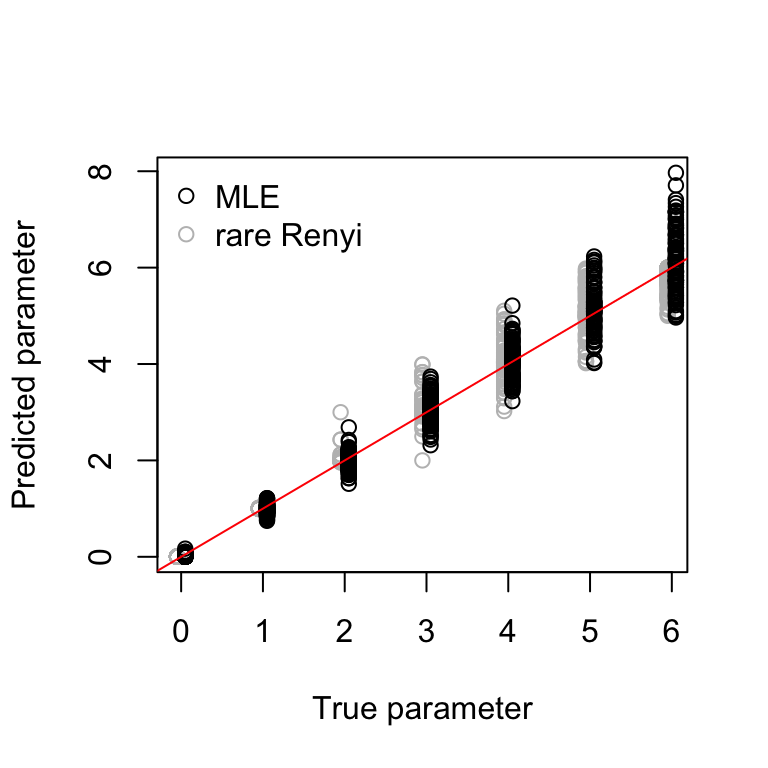

```r
# maximum likelihood estimation with *pika*
mle <- sapply(allSAD, function(x) {sad(x, 'tnegb')$MLE[2]})

plot(allParam - 0.05, rfRare$predicted, xlab = 'True parameter',
     ylab = 'Predicted parameter', col = 'gray',
     ylim = range(mle, rfRare$predicted))
points(allParam + 0.05, mle)
abline(0, 1, col = 'red')
legend('topleft', legend = c('MLE', 'rare Renyi'), col = c('black', 'gray'),
       pch = 1, bty = 'n')
```

So my take home is that RF on rare Renyi is better for negative binomial when $k$ is small, but is a less consistent estimator (i.e. the mean of the inferred parameter can be off) than ML. That makes sense, ML is provably least biased for $n$ approaching infinity. But maybe with more Renyi entropies RF would do just as good.